# Covid91 vaccine study Final2020

Jonathan Paul Clavio

Oct 27, 2020

# Introduction

A new preventative vaccine (covid91) is under test in clinical trials. Given the nature of this vaccine it is suspected that the drug may exhibit different effectiveness across the variety of subpopulations tracked. The analysis of this new drug will be done across four target subgroups; gender, lgbtq, and the drug users.

$H_0$: The Null Hypothesis is that among the target population, the vaccine has no effect on whether they contract the virus or not.

$H_A$: The Alternative Hypothesis is that among the target population, the vaccine has an effect on whether they contract the virus or not.

# Methods

Every question is of a Cat~Cat type.

## Results

#### Female Graphical Results

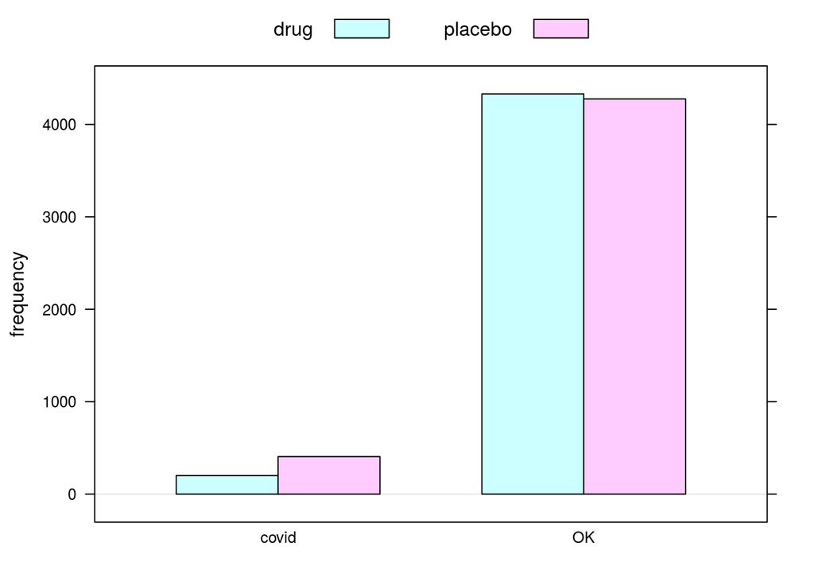

```r
dataf = filter(FinalData, sex=="gal")
barchartGC(~infected + treatment,data=dataf)
```

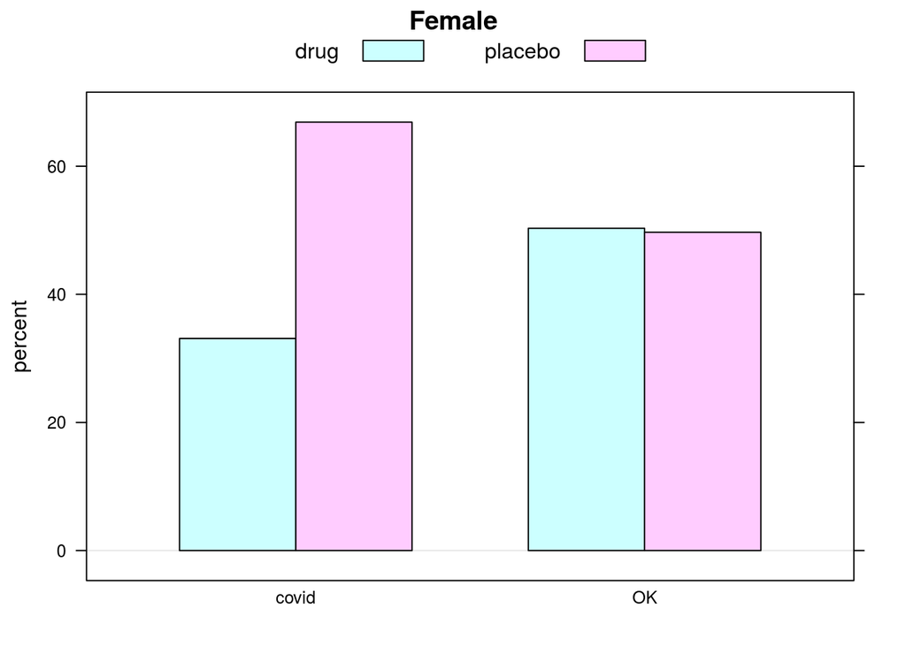

```r
barchartGC(~infected + treatment,data=dataf, type="percent", main="Female")
```

Among the females who had COVID-19, It appears that those who had COVID-19 and took the drug, the vaccine does have an positive effect.

#### Male Graphical Results

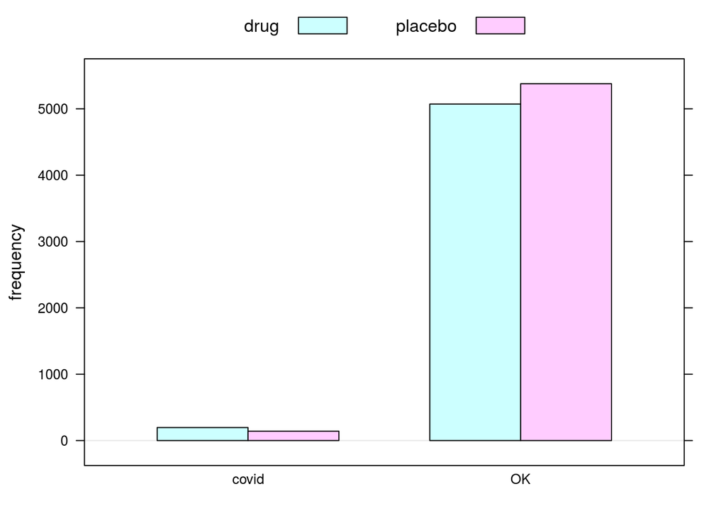

```r
datag = filter(FinalData, sex=="guy")
barchartGC(~infected + treatment,data=datag)
```

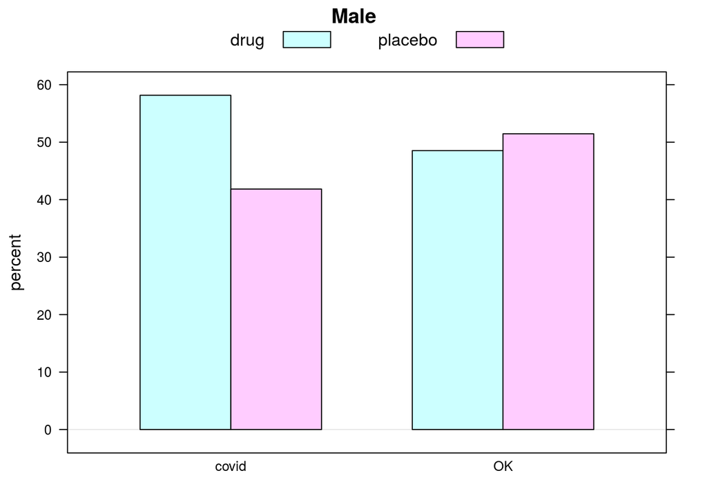

```r
barchartGC(~infected + treatment,data=datag, type="percent", main="Male")
```

Among the males who had COVID-19, it appears those who had took vaccine has a negative effect in that the males who take the vaccine will be more likely to get COVID-19.

#### LGBTQ Graphical Results

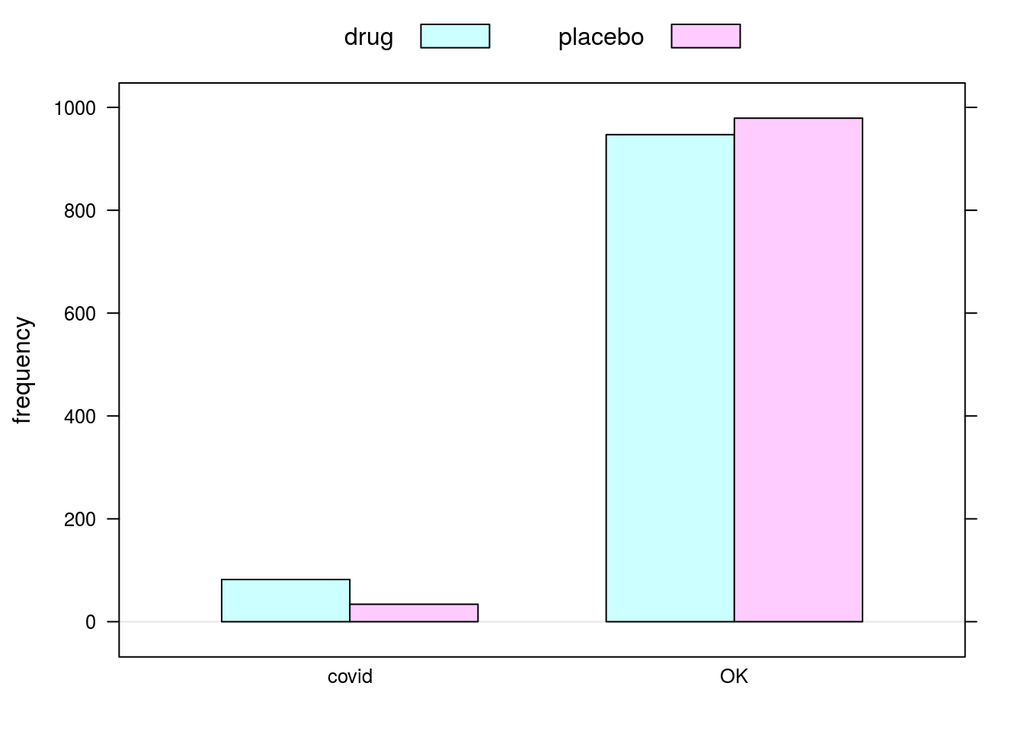

```r
datal= filter(FinalData, LGBTQ=="gay")
barchartGC(~infected + treatment,data=datal)
```

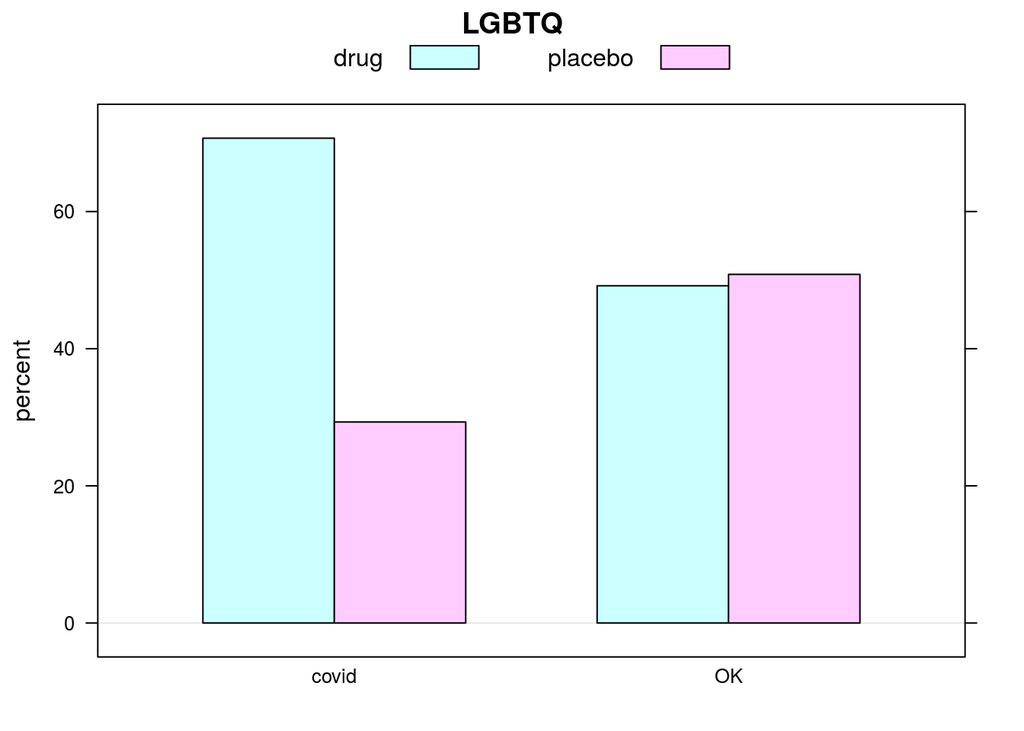

```r
barchartGC(~infected + treatment,data=datal, type="percent", main="LGBTQ")
```

Among the LGBTQ community who had COVID-19, it appears those who had took the vaccine has a negative effect in that those in the LGBTQ community who has taken it will be more likely to get COVID-19.